$\def \d \ensuremath{\mathbf{d}}$ $\def \e \ensuremath{\mathbf{e}}$ $\def \g \ensuremath{\mathbf{g}}$ $\def \I \ensuremath{\mathbf{I}}$ $\def \l \ensuremath{\mathbf{l}}$ $\def \M \ensuremath{\mathbf{M}}$ $\def \W \ensuremath{\mathbf{W}}$ $\def \Omegab \ensuremath{\boldsymbol{\Omega}}$

# Assignment on Statistical Computing

Bayesian Analysis of the Challenger Data

Bhargob Kakoty

MStat Student

Roll No.- MD-1905

03/12/2020

# 1 The Challenger Data

The Challenger formed the main backbone of investigation of the disaster where NASA’s space shuttle named “Challenger” crashed a few minutes after its launch on 28 January, 1986. The Presidential Commission’s report outlined that the cause of the incident was mainly the failure of an device called “O-Rings” which sealed a joint in the booster rockets. It was also mentioned that the failure was perhaps due to extreme low temperature which in turn affected the rings creating a leak of combustion gases. The Challenger data set contains data on number of accidents related to “O-Rings”, and some other potential variables (e.g. pressure and temperature during the time of launch) from $23$ pre-accidental space shuttles. We present the data below:-

```r
challenger<-read.csv("https://raw.githubusercontent.com/egarpor/handy/master/datasets/challenger.txt", sep="", header = TRUE)
challenger
```

| flight | date | nfails.field | nfails.nozzle | fail.field | fail.nozzle | temp | pres.field | pres.nozzle |
| --- | --- | --- | --- | --- | --- | --- | --- | --- |
| 1 | 12/04/81 | 0 | 0 | 0 | 0 | 18.9 | 50 | 50 |
| 2 | 12/11/81 | 1 | 0 | 1 | 0 | 21.1 | 50 | 50 |
| 3 | 22/03/82 | 0 | 0 | 0 | 0 | 20.6 | 50 | 50 |
| 5 | 11/11/82 | 0 | 0 | 0 | 0 | 20.0 | 50 | 50 |
| 6 | 04/04/83 | 0 | 2 | 0 | 1 | 19.4 | 50 | 50 |
| 7 | 18/06/83 | 0 | 0 | 0 | 0 | 22.2 | 50 | 50 |
| 8 | 30/08/83 | 0 | 0 | 0 | 0 | 22.8 | 100 | 50 |
| 9 | 28/11/83 | 0 | 0 | 0 | 0 | 21.1 | 100 | 100 |
| 41-B | 03/02/84 | 1 | 1 | 1 | 1 | 13.9 | 100 | 100 |
| 41-C | 06/04/84 | 1 | 1 | 1 | 1 | 17.2 | 200 | 200 |

[output cut: 13 more lines]

# 2 Towards choosing a Bayesian model

In bayesian theory we always try to quantify our uncertainty about the values of the fixed parameters by taking a prior distribution based on our apriori belief which when combined with the likelihood of the observations results in the updated posterior information about the parameters. In our problem, we are going to consider `fail.field` as our response variable. The $i^{th}$ response $y_i$ ($i=1,2, \dots 23$ in our case) can be considered as observation from a Bernoulli distribution with success probability $p_i$. A logistic regression model uses the logit link to relate log odds of success to a linear combination of predictors. Since in our case, the only predictor is temperature (let denote $t_i$) so we have a following model
$$\log\left(\frac{p_i}{1-p_i}\right)=a+b*t_i \quad \quad i=1,2, \dots 23$$
. The likelihood is $l(a,b|data) = \frac{\exp(a\sum_{i=1}^{23} y_i+b\sum_{i=1}^{23} t_iy_i)}{\Pi_{i=1}^{23}(1+exp(a+bt_i))}$. If our uncertainty about parameter $(a,b)$ is quantified by prior distribution $\pi(a,b)$ then our posterior is $\pi(a,b|data) \propto \pi(a,b)\frac{\exp(a\sum_{i=1}^{23} y_i+b\sum_{i=1}^{23} t_iy_i)}{\Pi_{i=1}^{23}(1+exp(a+bt_i))}$. Choosing a prior one of the concerns in bayesian analysis. There are some methods which help us to choose prior based on optimizing information criteria or based on some frequentist ideas etc. However, for simplicity we will be working with flat uniform prior on $(a,b)$ over $\mathbb{R} \times \mathbb{R}$. In otherwords, $\pi(a,b) \propto 1, \quad \forall (a,b) \in \mathbb{R} \times \mathbb{R}$. Now, under such a prior our posterior becomes proportional to the likelihood $l(a,b|data)$. However, this posterior does not seem to be tractable enough to allow us to draw samples directly from it. So, we would take resort to Markov Chain Monte Carlo (MCMC) techniques to draw samples from this posterior.

# 3 MCMC-MH Algorithm

## 3.1 Choice of Prior and Proposal

```r
logis<-glm(fail.field~ temp, data=challenger, family="binomial")
logis$coefficients
```

```
## (Intercept)        temp
##   7.5837433  -0.4166465
```

```r
#code to generate "target.png" (the posterior density)

target<-function(a,b){

  m<-mean(challenger[,5])
  n<-mean(  challenger[,5] *challenger[,7] )
  a1<-exp(a*23*m+ b*23*n)
s<-rep(0,23)
for(i in 1:23)
{
  s[i]<-1+exp(a+b*challenger[,7][i])
}
q=prod(s)
i<-a1/q

  return(i)


}

x<-seq(5,9, by=0.03)
y<-seq(-0.7,-0.3, by= 0.003)
z<-matrix(0, nrow=length(x), ncol=length(y))

for(i in 1:length(x)){
  for( j in 1:length(y)){
  z[i,j]<-target(x[i], y[j])

  }

}




t<-persp(x,y,z, theta=40, phi=10, r=4, shade=0.5, axes=TRUE,scale=TRUE, box=TRUE,

               nticks=5, ticktype="detailed", zlim = c(0, 0.00005) , col="yellow", xlab="a",

              ylab="b", zlab="f", main="target posterior(upto a constant")
```

```r
# The image obtained was zoomed and saved as a file and was added externally to our report
```

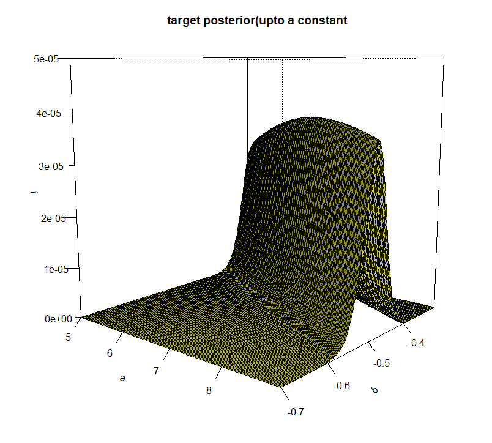

```r
knitr::include_graphics("target.png")
```

Looking at the surface it seems like that it is the bivariate generalization of a heavy tailed distribution. To make sure that the proposal has same support as posterior we tried considering bivariate Cauchy distribution with location parameter same as mle’s and varying scale matrix and matched the shape with the posterior. A hit and trial method results in a cauchy distribution with diagonal scale matrix with $20$ and $0.01$ in the diagonal. Its shape is as follows:-

```r
## Generating the image "cauchy_prop.png"
library(LaplacesDemon)
bcauchy<-function(a,b){
  return(dmvc( c(a,b), c(7.584,-0.417), matrix(c(20, 0, 0, 0.01), nrow=2, ncol=2)))
}



x<-seq(4,9, by=0.1)
y<-seq(-0.7,-0.2, by= 0.01)
z<-matrix(0, nrow=length(x), ncol=length(y))

for(i in 1:length(x)){
  for( j in 1:length(y)){
    z[i,j]<-bcauchy(x[i], y[j])

  }

}





s<-persp(x,y,z, theta=45, phi=10, r=4, shade=0.5, axes=TRUE,scale=TRUE, box=TRUE,

      nticks=5, ticktype="detailed", zlim = c(0, 0.4) , col="yellow", xlab="a",

      ylab="b", zlab="f", main="cauchy proposal")
```

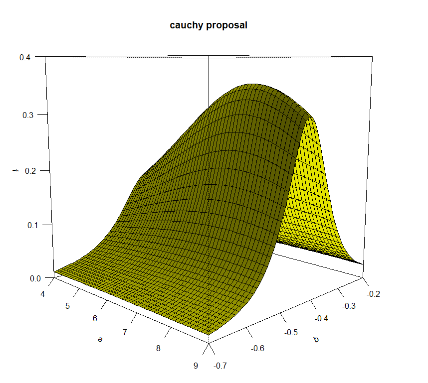

```r
knitr::include_graphics("cauchy_prop.png")
```

When compared with the posterior surface we can see that it has similar kind of shape (not exactly same though). We guess taking such a proposal which matches with target distribution upto at least certain extent would help us.

As we will see below, this proposal also satisfies the condition mentioned in Jones Hobert[1]. For this we consider $\log\left(\frac{\pi(.|data)}{q(.)}\right)=\log(\pi(.|data))-\log(q(.))$ and try to see if it attains maximum over a bounded support.Then we will see if the maximum changes if the support range is gradually increased. Because of computational complexity of large numbers by `R` we will perform the task for three different ranges viz.:- (1) $(-100,100) \times (-10,10)$, (2) $(-150,150) \times (-15,15)$, and (3)$(-200,200) \times (-20,20)$.

```r
lcauchy<-function(a,b){
  return(log(bcauchy(a,b)))
}

ltarget<-function(a,b){

  m<-mean(challenger[,5])
  n<-mean(  challenger[,5] *challenger[,7] )
  a1<-a*23*m+ b*23*n
  s<-rep(0,23)
  for(i in 1:23)
  {
    s[i]<-log(1+exp(a+b*challenger[,7][i]))
  }
  q=sum(s)
  i<-a1-q

  return(i)


}

x<-seq(-100,100, by=1)
y<-seq(-10,10, by= 0.1)
z<-matrix(0, nrow=length(x), ncol=length(y))


for(i in 1:length(x)){
  for( j in 1:length(y)){
    z[i,j]<-ltarget(x[i], y[j])-lcauchy(x[i], y[j])

  }

}


max(z)
```

```
## [1] -5.941494
```

```r
x<-seq(-150,150, by=1)
y<-seq(-15,15, by= 0.1)
z<-matrix(0, nrow=length(x), ncol=length(y))


for(i in 1:length(x)){
  for( j in 1:length(y)){
    z[i,j]<-ltarget(x[i], y[j])-lcauchy(x[i], y[j])

  }

}
 max(z)
```

```
## [1] -5.941494
```

```r
 x<-seq(-200,200, by=1)
 y<-seq(-20,20, by= 0.1)
 z<-matrix(0, nrow=length(x), ncol=length(y))


 for(i in 1:length(x)){
   for( j in 1:length(y)){
     z[i,j]<-ltarget(x[i], y[j])-lcauchy(x[i], y[j])

   }

 }

 max(z)
```

```
## [1] -5.941494
```

As we can see the maximum value remains the same over the three ranges. This is also evident from the following surface plot of the log ratio:-

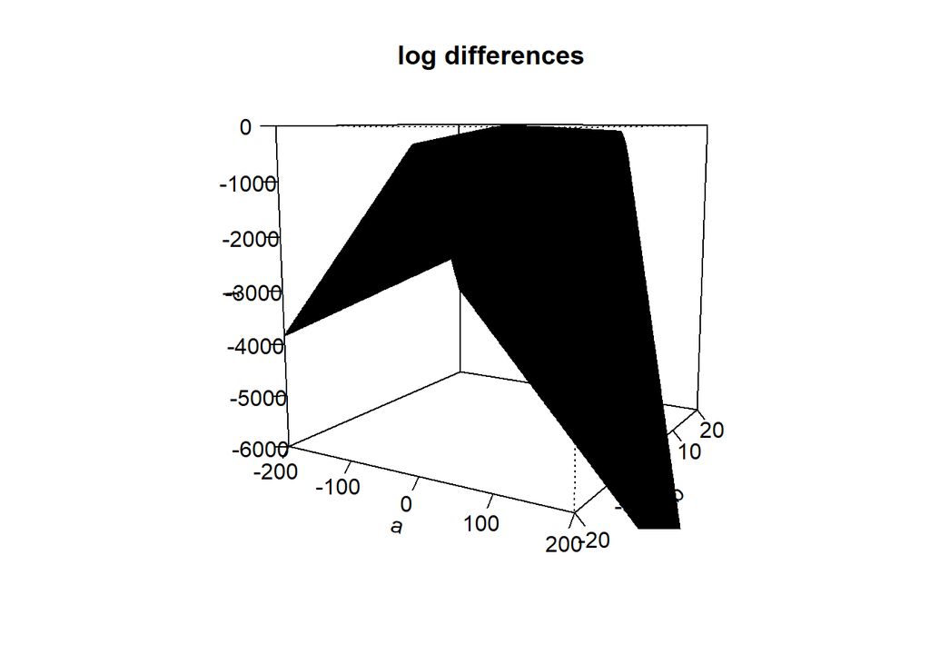

```r
persp(x,y,z, theta=30, phi=10, r=4, shade=0.5, axes=TRUE,scale=TRUE, box=TRUE,

      nticks=5, ticktype="detailed", zlim = c(-6000, 0 ) , col="yellow", xlab="a",

      ylab="b", zlab="f", main="log differences")
```

Thus we are ready to proceed with this proposal for doing rest of our analysis.

## 3.2 Generation of Markov Chain

To draw samples using the flat prior and the proposed proposal density, we now form our corresponding `R` functions which would run the algorithm.

```r
rbcauchy<-function(){
  return(   rmvc(n=1, c(7.584, -0.417), matrix(c(20, 0, 0, 0.01), nrow=2, ncol=2)        ))
}

## acceptance probability

accept1<-function(x,y){
  q1<-ltarget(x[1], x[2])
  q2<-ltarget(y[1],y[2])

    q<-(q2-q1)+log(( bcauchy(x[1],x[2])/bcauchy(y[1],y[2])    ))


  if (q<=0){
    return(exp(q))
  }
  else{
    return(1)
  }
}

metropolis1<-function(initial, k){
  s<-list()
  s[[1]]<-c(0,0)
  for(i in 2:k) {

    s[[i]]<-s[[(i-1)]]

  }

  s[[1]]<-initial

  for(i in 2:k){



      al<- rbcauchy()

    al<- as.vector(al)
    pl<-  accept1(s[[i-1]], al)

    pll<-sample(c(1:2), 1, prob=c(pl, 1-pl))

    if(pll==1){
      s[[i]]<-al
    }

    else{
      s[[i]]<-s[[i-1]]
    }

  }


  return(s)

}
```

The function `metropolis1` returns a list of $k$ many samples drawn by M-H algorithm for a initial value of $(a,b)$. We take the mle’s as our initial values and we generate 50000 samples. A sample of $20$ samples are shown below.Each row denote a sample.

```r
set.seed(34)
t<-metropolis1( c(7.5837, -0.4166), 50000)
M<-matrix(0, nrow=length(t), ncol=2)
for(i in 1: length(t)){
  M[i,]<- t[[i]]
}

M[1:20,1:2]
```

```
##            [,1]       [,2]
##  [1,]  7.583700 -0.4166000
##  [2,]  7.583700 -0.4166000
##  [3,]  7.583700 -0.4166000
##  [4,]  7.583700 -0.4166000
##  [5,]  7.583700 -0.4166000
##  [6,]  7.583700 -0.4166000
##  [7,]  7.583700 -0.4166000
##  [8,]  7.583700 -0.4166000
##  [9,]  9.760916 -0.4885770
## [10,]  9.760916 -0.4885770
## [11,] 11.008885 -0.5620752
## [12,] 11.008885 -0.5620752
## [13,] 11.008885 -0.5620752
## [14,] 11.008885 -0.5620752
## [15,] 11.008885 -0.5620752
## [16,] 11.008885 -0.5620752
## [17,]  6.368822 -0.3635095
## [18,]  6.368822 -0.3635095
## [19,]  6.368822 -0.3635095
## [20,]  6.368822 -0.3635095
```

Now, a scatter plot of the generated sample $(a,b)$ values is shown below:-

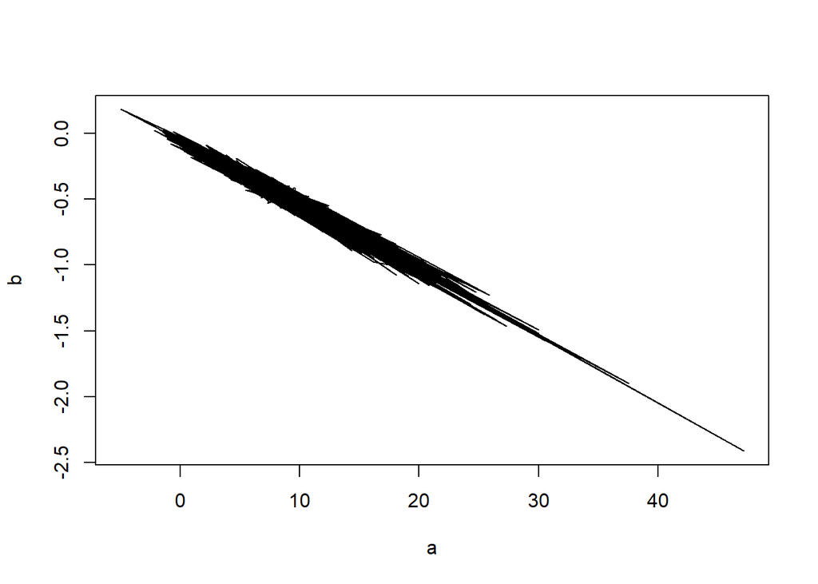

```r
a<-M[,1]
b<-M[,2]
plot(a, b, type="l")
```

The histogram of $a$ values and $b$ values are shown below separately:-

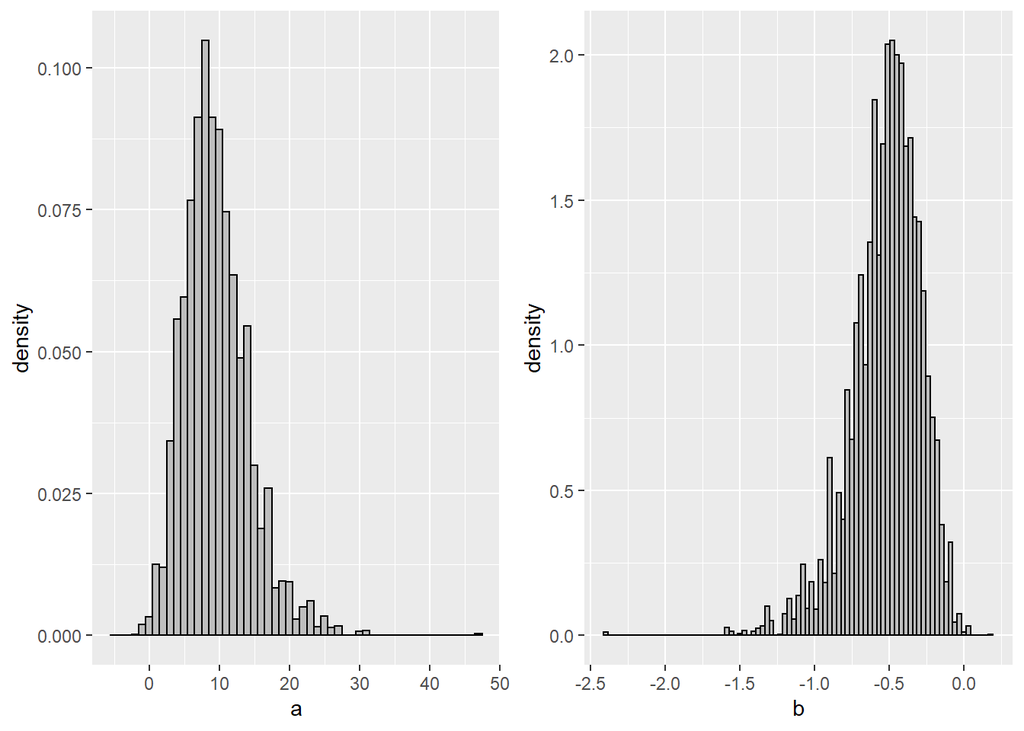

```r
library(ggplot2)
library(gridExtra)
data<-as.data.frame(M)
colnames(data)<-c("a","b")

p<-ggplot(data) +
    geom_histogram(aes(x = a, y = ..density..),
                   binwidth = 1, fill = "grey", color = "black")

q<-ggplot(data) +
    geom_histogram(aes(x = b, y = ..density..),
                   binwidth = 0.03, fill = "grey", color = "black")

grid.arrange(p,q, ncol=2)
```

The histogram of $a$ values appear to be a positively skewed distribution, whereas that of $b$ values appears as heavily negatively skewed one.

We can get the estimates of $a$ and $b$ by taking mean of this posterior samples.

```r
s1<-mean(a)
s2<-mean(b)
```

Now, we can find the standard error of these posterior estimates by using method of batch means as mentioned in Jones & Hobert[1]. Let us take batches of size $5000$ to get $10$ samples of $S_k^a=\frac{1}{5000} \sum_{i=5000(k-1)}^{5000k-1}a_i$. Then we can use the formula mentioned in the paper. Similar formula can be applied for $b$ values too.

```r
m1<-rep(0,10)
m2<-rep(0,10)
for(i in 1:10){
  w<-5000*(i-1)+1
  e<-(5000*i)
 m1[i]<-(1/5000)* sum(a[w:e])
 m2[i] <-(1/5000)* sum(b[w:e])

}

sqrt(5000*var(m1))
```

```
## [1] 31.03624
```

```r
sqrt(5000*var(m2))
```

```
## [1] 1.472421
```

So we see that the estimates of standard errors are high. And, it perhaps tells us that we should have generated even more samples so that we could have taken more higher batch size. This might happen because we are not considering any burn-in in our case as it often termed as unnecessary (as mentioned in http://users.stat.umn.edu/~geyer/mcmc/burn.html)

# 4 On Convergence Diagnostics

Let us see the time series plot for both the $a$ sample vales and $b$ sample values.

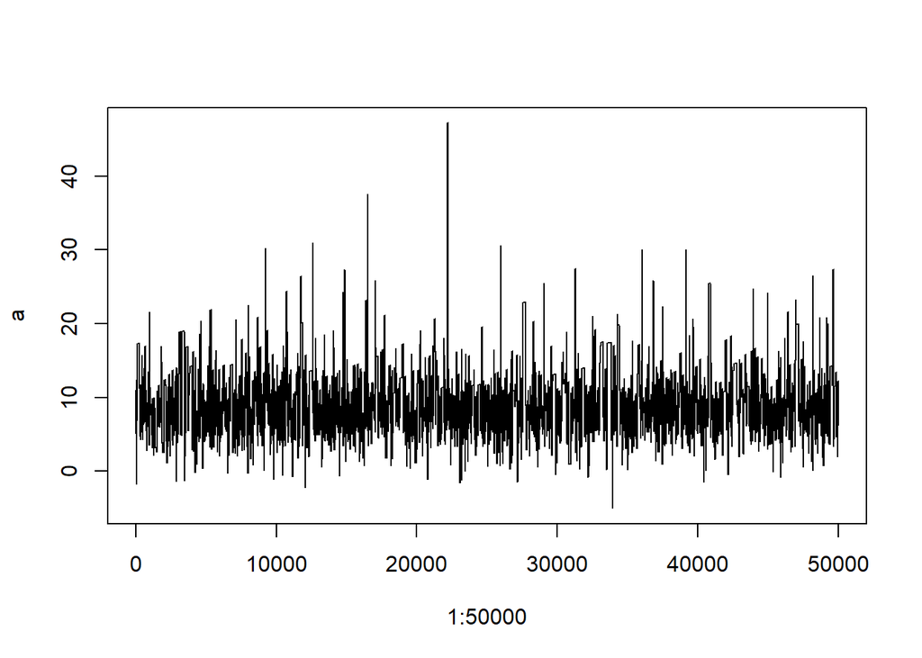

```r
plot(1:50000, a, type="l")
```

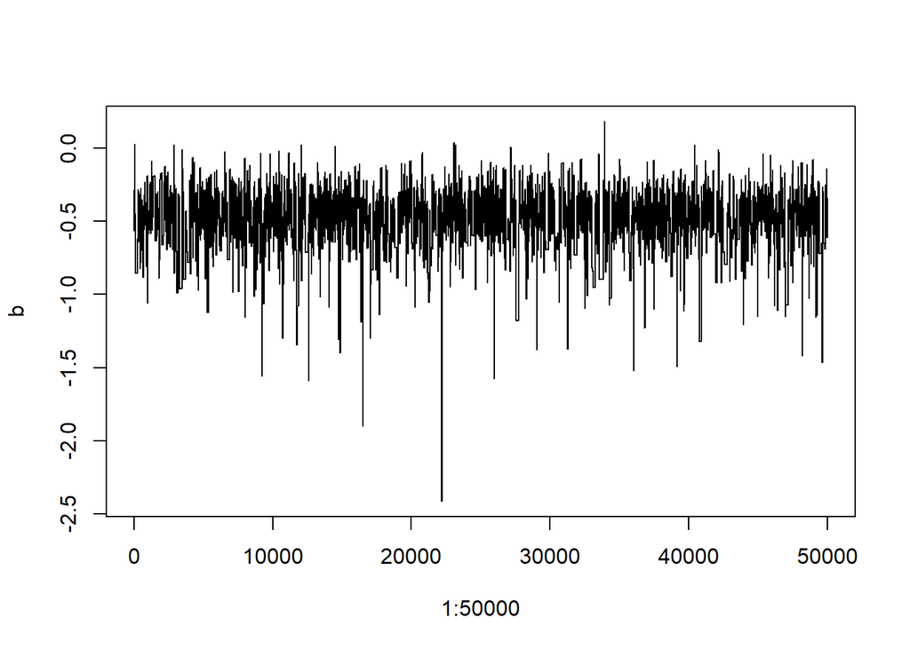

```r
plot(1:50000,b, type="l")
```

It can be seen that they more or less look like a “black hair caterpillar”. So it seems like that the chain does not get stuck in some part of the parameter space, and explores the parameter space fully. This indicates a well converging pattern.

Secondly, we consider the sample auto-covariance function versus lags plot of both the quantities. A good chain should show a decreasing pattern.

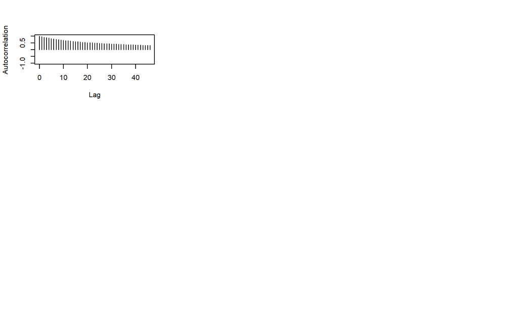

```r
library(coda)
autocorr.plot(a)
```

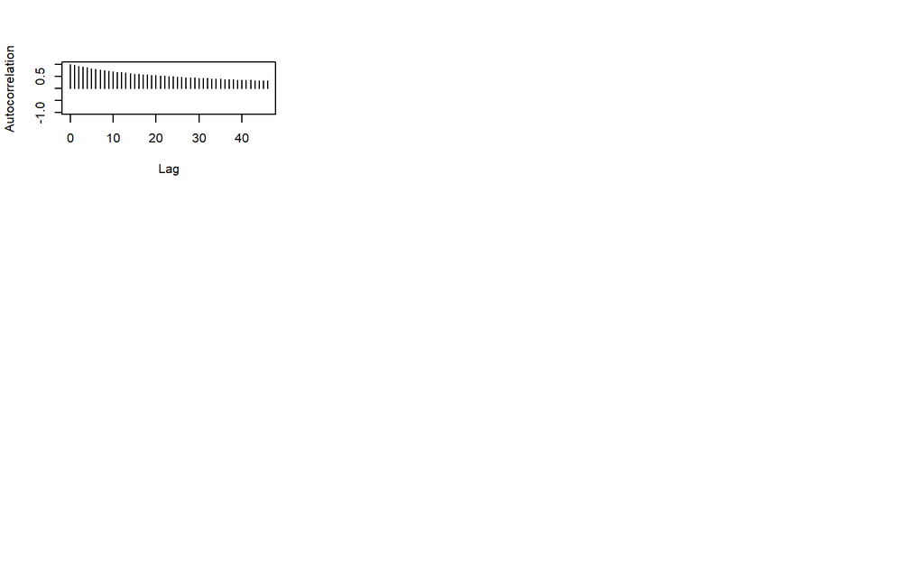

```r
autocorr.plot(b)
```

Since the plots shows a decreasing pattern we can say that as iteration is increasing the samples’ correlation is reducing and they would eventually behave as i.i.d.

We can also test the convergence formally by Geweke’s convergence diagnostic. This test is based on test of equality of means of first part ($10$ percent) and last part ($50$ percent of the data). If the samples are drawn from stationary distribution the two means are equal and Geweke’s statistic has an asymptotically standard normal distribution. The function `geweke.diag` from `coda` package would give use the value of test statistic (a standard $z$ score) for each parameter separately.

```r
library(coda)
M1<-as.mcmc(M)
geweke.diag(M1, frac1=0.1, frac2=0.5)
```

```
##
## Fraction in 1st window = 0.1
## Fraction in 2nd window = 0.5
##
##    var1    var2
## -0.4520  0.4146
```

Normally if observed $z$ values lie in the range $\{z:|z|>1.96\}$, then it becomes problematic. But in our case it turns out there is no problem.

# 5 Posterior Inference

The negative skewness of the histogram of the $b$ values is clearly showing that $b$, the coefficient of temperature in the true model is very likely to assume a negative value. It indicates a negative dependence on the temperature. Secondly, we already know that “Challenger” crashed at $-0.6$ degree celcius. So, putting $t_i=-0.6$ in our logistic regression model we have $p_i=\frac{\exp(a-0.6b)}{1+\exp(a-0.6b)}$. Given that we now have a well behaved sample from posterior distribution of $(a,b)$, we can try to find out the histogram of this quantity $p_i$.

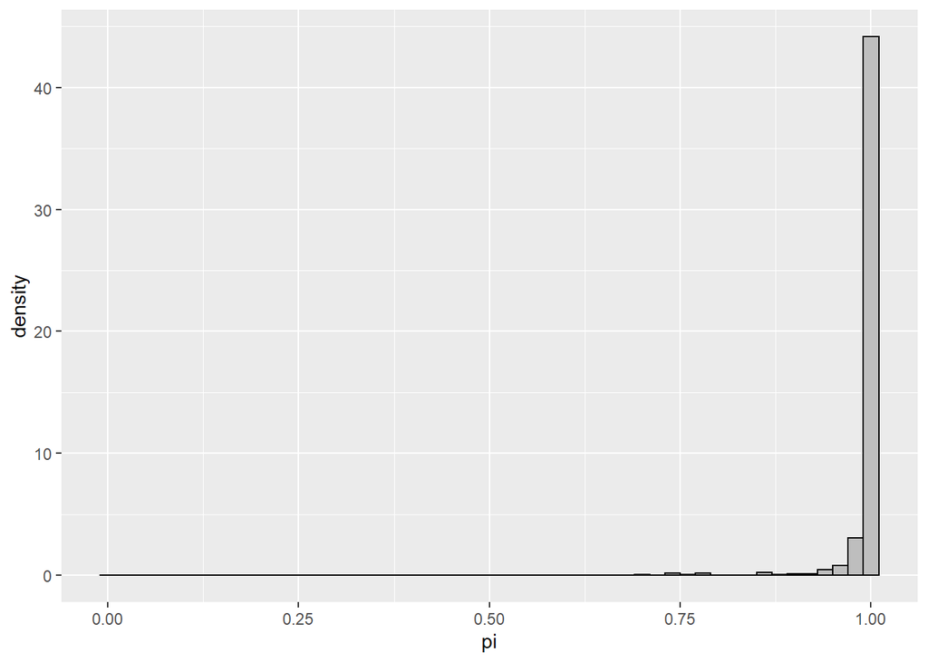

```r
ps<-function(x){
  c<-exp(x[1]-(0.6*x[2]))
  return(c/(1+c))
}
pi<-apply(M,1, ps)


data<-as.data.frame(pi)
p1<-ggplot(data) +
    geom_histogram(aes(x = pi, y = ..density..),
                   binwidth =0.02, fill = "grey", color = "black")
p1
```

So, we can see that this appears distribution with negative skew and mainly concentrated around 1. So, the posterior probability that “Challenger” would face at least one failure due to “O-Rings” was very high given the data and temperature $-0.6$ degree celcius. We can also do one thing. We can generate similar kind of histograms under different temperatures and can find the distribution of posterior probability.

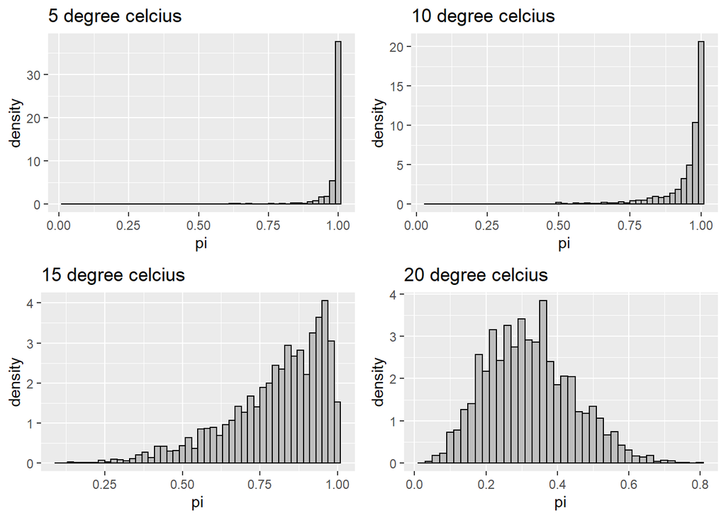

```r
ps<-function(x){
  c<-exp(x[1]+(5*x[2]))
  return(c/(1+c))
}

pi<-apply(M,1,ps)
s<-mean(pi)
data<-as.data.frame(pi)
p1<-ggplot(data) +
    geom_histogram(aes(x = pi, y = ..density..),
                   binwidth =0.02, fill = "grey", color = "black")
h1<-p1+labs(title="5 degree celcius")

ps<-function(x){
  c<-exp(x[1]+(10*x[2]))
  return(c/(1+c))
}

pi<-apply(M,1,ps)
s<-mean(pi)
data<-as.data.frame(pi)
p1<-ggplot(data) +
    geom_histogram(aes(x = pi, y = ..density..),
                   binwidth =0.02, fill = "grey", color = "black")
h2<-p1+labs(title="10 degree celcius")

ps<-function(x){
  c<-exp(x[1]+(15*x[2]))
  return(c/(1+c))
}

pi<-apply(M,1,ps)
s<-mean(pi)
data<-as.data.frame(pi)
p1<-ggplot(data) +
    geom_histogram(aes(x = pi, y = ..density..),
                   binwidth =0.02, fill = "grey", color = "black")
h3<-p1+labs(title="15 degree celcius")

ps<-function(x){
  c<-exp(x[1]+(20*x[2]))
  return(c/(1+c))
}

pi<-apply(M,1,ps)
s<-mean(pi)
data<-as.data.frame(pi)
p1<-ggplot(data) +
    geom_histogram(aes(x = pi, y = ..density..),
                   binwidth =0.02, fill = "grey", color = "black")
h4<-p1+labs(title="20 degree celcius")

grid.arrange(h1,h2,h3,h4, nrow=2, ncol=2)
```

# 6 References

$(1):-$ Jones, Galin L.; Hobert, James P. Honest Exploration of Intractable Probability Distributions via Markov Chain Monte Carlo. Statist. Sci. 16 (2001), no. 4, 312–334. $(2):-$ Siddhartha, R. D., E. B. Fowlkes, and B. Hoadley. 1989. “Risk Analysis of the Space Shuttle: Pre-Challenger Prediction of Failure.” Journal of the American Statistical Association 84 (408): 945–57. $(3):-$ J. Ghosh, M. Delampady, and T. Samanta, An Introduction to Bayesian Analysis, Springer, New York, 2006.